# BAA1030 Assignment 2 - Child Mortality Analysis

Author

Zahin Izhar Azahir

# Executive Summary

This dashboard presents a global analysis of child mortality, focusing on countries most affected, the economic factors linked to survival rates, and the worldwide trends in reducing child deaths. Through visual storytelling, the report highlights key areas where significant progress has been made — and where urgent interventions are still needed.

# Introduction

Child mortality remains one of the most pressing global health challenges, particularly in low- and middle-income countries. This report examines child deaths across nations, investigates how economic development relates to survival outcomes, and tracks the overall progress made in reducing child mortality over time. By understanding these patterns, we can better target policies and interventions to save lives.

# Data Loading and Preparation

```python
import polars as pl
import plotnine as pn
import geopandas as gpd
import matplotlib.pyplot as plt

# Load data
indicator_2 = pl.read_csv("unicef_indicator_2.csv")
```

# Data Cleaning and Transformation

```python
# Focus on relevant indicator: Deaths age 1-59 months
child_deaths = indicator_2.filter(pl.col("indicator") == "Deaths age 1-59 months")

# Grouping by country and year
child_deaths_grouped = child_deaths.select([
    "country", "time_period", "obs_value"
])

# Global trend (sum across all countries per year)
global_deaths = child_deaths_grouped.group_by("time_period").agg(
    pl.col("obs_value").sum().alias("total_deaths")
)

# Get latest year for each country
latest_year = child_deaths_grouped.group_by("country").agg(
    pl.col("time_period").max().alias("latest_year")
)

# Join based only on "country"
latest_deaths = child_deaths_grouped.join(latest_year, on="country")

# Filter to keep only records with the latest year
latest_deaths = latest_deaths.filter(
    pl.col("time_period") == pl.col("latest_year")
)
```

# Global Overview

## World Map: Global Child Mortality (Latest Available Year)

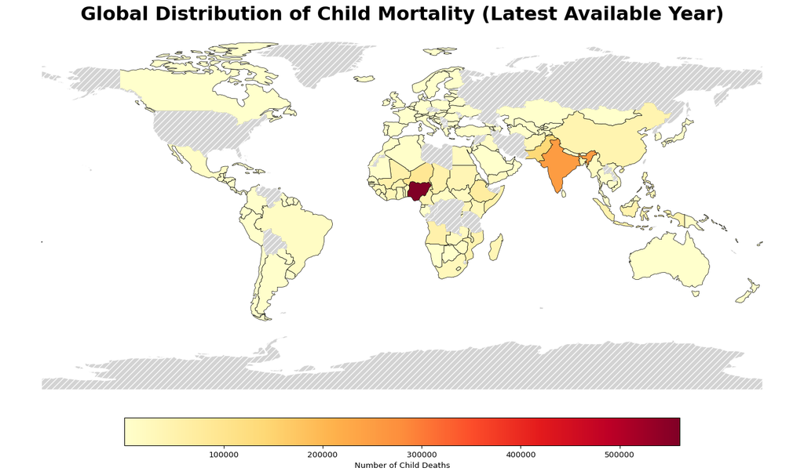

```python
# Load manually downloaded Natural Earth shapefile
world = gpd.read_file("data/ne_110m_admin_0_countries.shp")

# Prepare deaths data
deaths_map_data = latest_deaths.to_pandas()
deaths_map_data = deaths_map_data.rename(columns={"country": "ADMIN"})

# Merge deaths with world map
world_deaths = world.merge(deaths_map_data, on="ADMIN", how="left")

# Plot World Map
fig, ax = plt.subplots(figsize=(18, 12))

world_deaths.plot(
    column="obs_value",
    cmap="YlOrRd",
    linewidth=0.5,
    ax=ax,
    edgecolor="black",
    legend=True,
    legend_kwds={
        'label': "Number of Child Deaths",
        'orientation': "horizontal",
        'shrink': 0.7,
        'pad': 0.02
    },
    missing_kwds={
        "color": "lightgrey",
        "edgecolor": "white",
        "hatch": "///",
        "label": "No Data Available"
    }
)

ax.set_title("Global Distribution of Child Mortality (Latest Available Year)", fontdict={
    'fontsize': 24, 'fontweight': 'bold'
})
ax.set_axis_off()
plt.show()
```

> **Note:** Darker colors represent higher child deaths; grey areas indicate no data.

# Impacted Countries

## Top 20 Countries (Child Deaths)

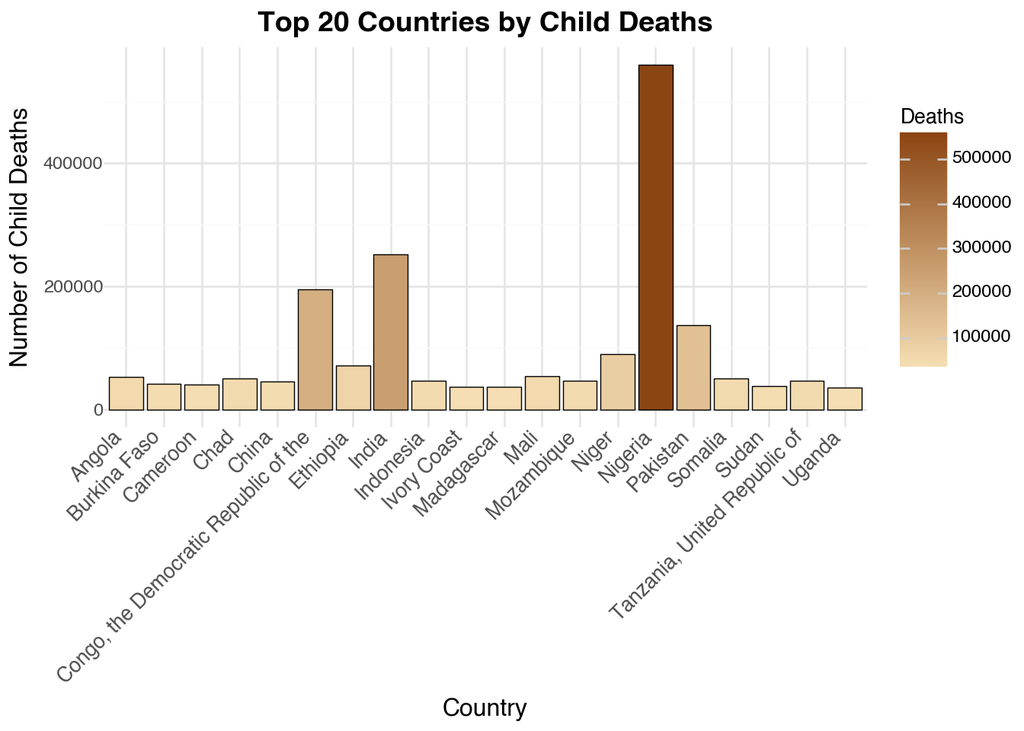

```python
# Select top 20 countries
top20_countries = latest_deaths.sort("obs_value", descending=True).head(20)

# Plot (polished)
pn.ggplot(top20_countries.to_pandas(), pn.aes(x='country', y='obs_value', fill='obs_value')) +\
    pn.geom_col(color="black", size=0.3) +\
    pn.scale_fill_gradient(low="#f5deb3", high="#8b4513", name="Deaths") +\
    pn.theme_minimal() +\
    pn.theme(
        axis_text_x=pn.element_text(rotation=45, hjust=1, size=10),
        axis_title=pn.element_text(size=12),
        plot_title=pn.element_text(size=14, weight="bold"),
        legend_title=pn.element_text(size=10)
    ) +\
    pn.labs(
        title="Top 20 Countries by Child Deaths",
        y="Number of Child Deaths",
        x="Country"
    )
```

# Economic Factors

## Relationship Between GDP and Child Deaths

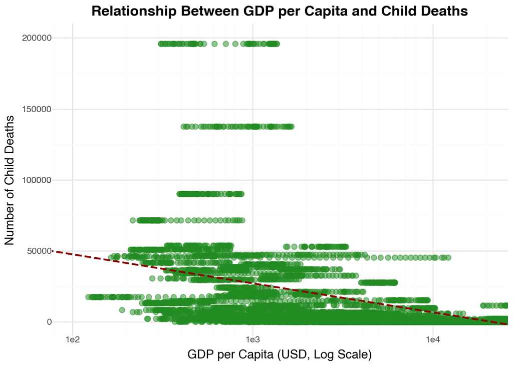

```python
# Load metadata
gdp_data = pl.read_csv("unicef_metadata.csv", infer_schema_length=10000)

# Merge GDP with child deaths
deaths_gdp = latest_deaths.join(
    gdp_data.select(["country", "GDP per capita (constant 2015 US$)"]),
    on="country"
)

# Drop rows with missing GDP values
deaths_gdp = deaths_gdp.drop_nulls()

# Improved Scatter Plot with linear model
pn.ggplot(deaths_gdp.to_pandas(), pn.aes(x='GDP per capita (constant 2015 US$)', y='obs_value')) +\
    pn.geom_point(color='forestgreen', alpha=0.5, size=2.5) +\
    pn.geom_smooth(method='lm', color='darkred', linetype='dashed', se=False) +\
    pn.scale_x_log10() +\
    pn.coord_cartesian(xlim=(100, 20000), ylim=(0, 200000)) +\
    pn.theme_minimal() +\
    pn.theme(
        axis_title=pn.element_text(size=12),
        plot_title=pn.element_text(size=14, weight="bold")
    ) +\
    pn.labs(
        title="Relationship Between GDP per Capita and Child Deaths",
        x="GDP per Capita (USD, Log Scale)",
        y="Number of Child Deaths"
    )
```

# Global Progress

## Global Trend in Child Mortality Over Time

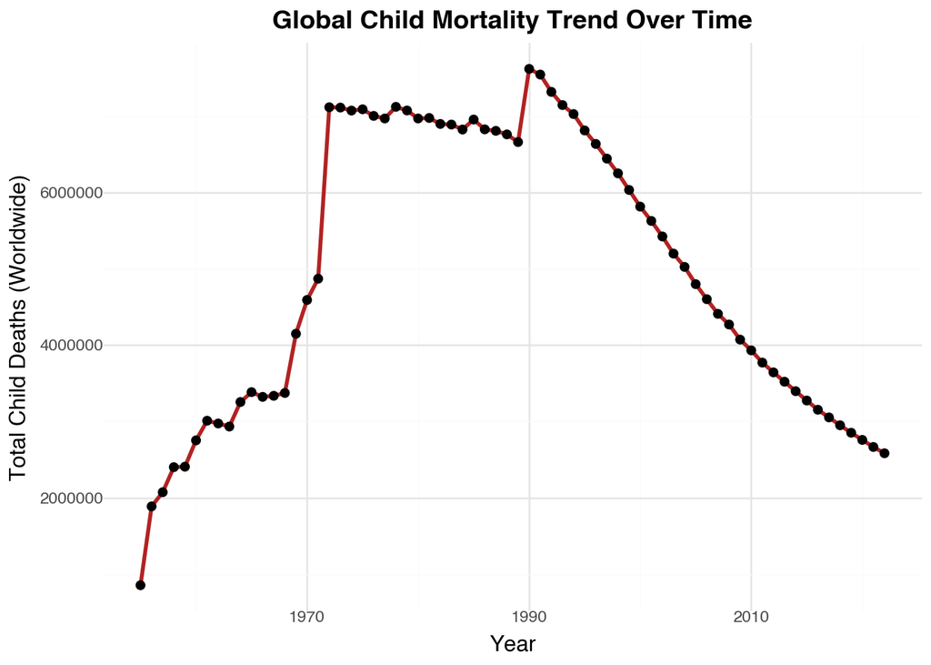

```python
# Plot Line Chart (polished)
pn.ggplot(global_deaths.to_pandas(), pn.aes(x='time_period', y='total_deaths')) +\
    pn.geom_line(color='firebrick', size=1.2) +\
    pn.geom_point(color='black', size=2) +\
    pn.theme_minimal() +\
    pn.theme(
        axis_title=pn.element_text(size=12),
        plot_title=pn.element_text(size=14, weight="bold")
    ) +\
    pn.labs(
        title="Global Child Mortality Trend Over Time",
        x="Year",
        y="Total Child Deaths (Worldwide)"
    )
```

# Conclusion